# DATA607_Week5_TidyTransform

Jerald Melukkaran

2025-03-04

### Introduction

In this exercise we import, tidy , transform and analyse flight data from a csv file that includes the counts of on time and delayed departure flights operated by Alaska air and AM WEST to 5 major cities in the united states.

### Data handling

The initial data set when imported looks like this

```
## Rows: 5
## Columns: 7
## $ V1 <chr> "Alaska", "", "", "AM WEST", ""
## $ V2 <chr> "on time", "delayed", "", "on time", "delayed"
## $ V3 <int> 497, 62, NA, 694, 117
## $ V4 <int> 221, 12, NA, 4840, 415
## $ V5 <int> 212, 20, NA, 383, 65
## $ V6 <int> 503, 102, NA, 320, 129
## $ V7 <int> 1841, 305, NA, 201, 61
```

We can now cleanup the empty row, add column names and add the Airline name to the second row

The Tidied data now looks like this

|  | Airline | Status | Los Angeles | Phoenix | San Diego | San Francisco | Seattle |
| --- | --- | --- | --- | --- | --- | --- | --- |
| 1 | Alaska | on time | 497 | 221 | 212 | 503 | 1841 |
| 2 | Alaska | delayed | 62 | 12 | 20 | 102 | 305 |
| 4 | AM WEST | on time | 694 | 4840 | 383 | 320 | 201 |
| 5 | AM WEST | delayed | 117 | 415 | 65 | 129 | 61 |

We can now transform the data into the standard form where all observations are rows and all columns are variables

| Airline | Status | City | Count |
| --- | --- | --- | --- |
| Alaska | on time | Los Angeles | 497 |
| Alaska | on time | Phoenix | 221 |
| Alaska | on time | San Diego | 212 |
| Alaska | on time | San Francisco | 503 |
| Alaska | on time | Seattle | 1841 |
| Alaska | delayed | Los Angeles | 62 |

### Analysis

With the data now tidy and transformed, the fist comparison made is between the on time and delayed flight numbers for both airlines across all 5 cities so that we have a basic overview

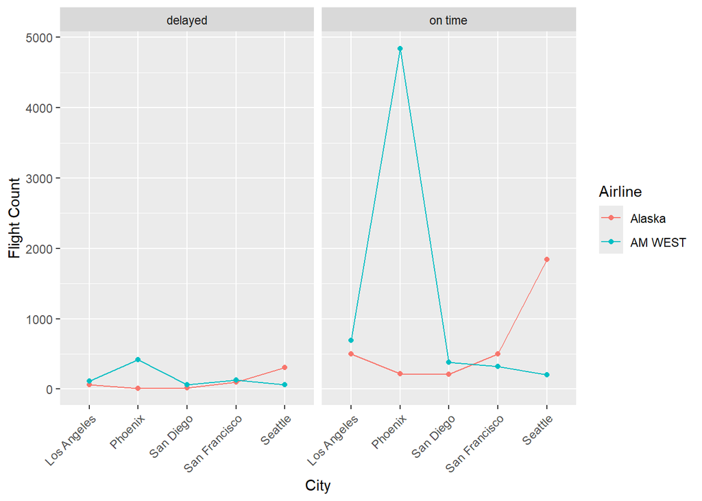

```r
ggplot(flight_data_tidy, aes(x = City, y = Count, color = Airline, group = Airline)) +
  geom_line() +
  geom_point() +
  labs(x = "City", y = "Flight Count") +
  facet_wrap(~ Status) +  # Facet by status
  theme(axis.text.x = element_text(angle = 45, hjust = 1))  # Angle x-axis
```

If we look at just Delayed flight numbers we might be led to believe that Alaska performs better in all cases except in Seattle, and if we only look at on time arrivals, we might be led to believe AM WEST does better expect in San Francisco and Seattle.

### Rate analyis

When considering data like this its important to bring flight volume into the equation. Knowing the proportion of delayed vs on-time flights will help us better analyse the trends in this data set. It will also be helpful if we can compare the overall stats for the airlines , and then break it down city by city

#### City Baseline

When analyzing overall rates for this data its important that we calculate some baseline stats for all 5 cities being studied. The most important stat here is the Average rate of delay that has been calculated for each city.

```r
flight_stats_city <- flight_data_tidy %>%
  group_by(City) %>%
  summarise(
    Total_Flights = sum(Count),  # Total flights (on-time + delayed)
    Delayed_Flights = sum(Count[Status == "delayed"]),  # Delayed flights
    OnTime_Flights = sum(Count[Status == "on time"]),  # On-time flights
    Rate_of_Delay = Delayed_Flights / Total_Flights  # Calculate the rate of delay
  )

knitr::kable(flight_stats_city,"simple")
```

| City | Total_Flights | Delayed_Flights | OnTime_Flights | Rate_of_Delay |
| --- | --- | --- | --- | --- |
| Los Angeles | 1370 | 179 | 1191 | 0.1306569 |
| Phoenix | 5488 | 427 | 5061 | 0.0778061 |
| San Diego | 680 | 85 | 595 | 0.1250000 |
| San Francisco | 1054 | 231 | 823 | 0.2191651 |
| Seattle | 2408 | 366 | 2042 | 0.1519934 |

#### Airline overall

We can also see how each airline does when taken as a whole without going city by city

```r
flight_stats_overall <- flight_data_tidy %>%
  group_by(Airline) %>%
  summarise(
    Total_Flights = sum(Count),  # Total flights (on-time + delayed)
    Delayed_Flights = sum(Count[Status == "delayed"]),  # Delayed flights
    OnTime_Flights = sum(Count[Status == "on time"]),  # On-time flights
    Rate_of_Delay = Delayed_Flights / Total_Flights  # Calculate the rate of delay
  )

knitr::kable(flight_stats_overall,"simple")
```

| Airline | Total_Flights | Delayed_Flights | OnTime_Flights | Rate_of_Delay |
| --- | --- | --- | --- | --- |
| AM WEST | 7225 | 787 | 6438 | 0.1089273 |
| Alaska | 3775 | 501 | 3274 | 0.1327152 |

Here we can see that Alaska has a slightly higher overall Rate of Delay compared to Alaska

#### Airline rates across each city

No we observe how each airline does individually by calculating their total delays compared to the total number of operated flights within each city .

```r
flight_stats <- flight_data_tidy %>%
  group_by(Airline, City) %>%
  summarise(
    Total_Flights = sum(Count),  # Total flights (on-time + delayed)
    Delayed_Flights = sum(Count[Status == "delayed"]),  # Delayed flights
    OnTime_Flights = sum(Count[Status == "on time"]),  # On-time flights
    Rate_of_Delay = Delayed_Flights / Total_Flights  # Calculate the rate of delay
  )

knitr::kable(flight_stats,"simple")
```

| Airline | City | Total_Flights | Delayed_Flights | OnTime_Flights | Rate_of_Delay |
| --- | --- | --- | --- | --- | --- |
| AM WEST | Los Angeles | 811 | 117 | 694 | 0.1442663 |
| AM WEST | Phoenix | 5255 | 415 | 4840 | 0.0789724 |
| AM WEST | San Diego | 448 | 65 | 383 | 0.1450893 |
| AM WEST | San Francisco | 449 | 129 | 320 | 0.2873051 |
| AM WEST | Seattle | 262 | 61 | 201 | 0.2328244 |
| Alaska | Los Angeles | 559 | 62 | 497 | 0.1109123 |
| Alaska | Phoenix | 233 | 12 | 221 | 0.0515021 |
| Alaska | San Diego | 232 | 20 | 212 | 0.0862069 |
| Alaska | San Francisco | 605 | 102 | 503 | 0.1685950 |
| Alaska | Seattle | 2146 | 305 | 1841 | 0.1421249 |

We can now bring it all together and plot the average rate of delays for Alaska and AM West and compare it against the average city rate of delay which is symbolized by the red dot in this plot

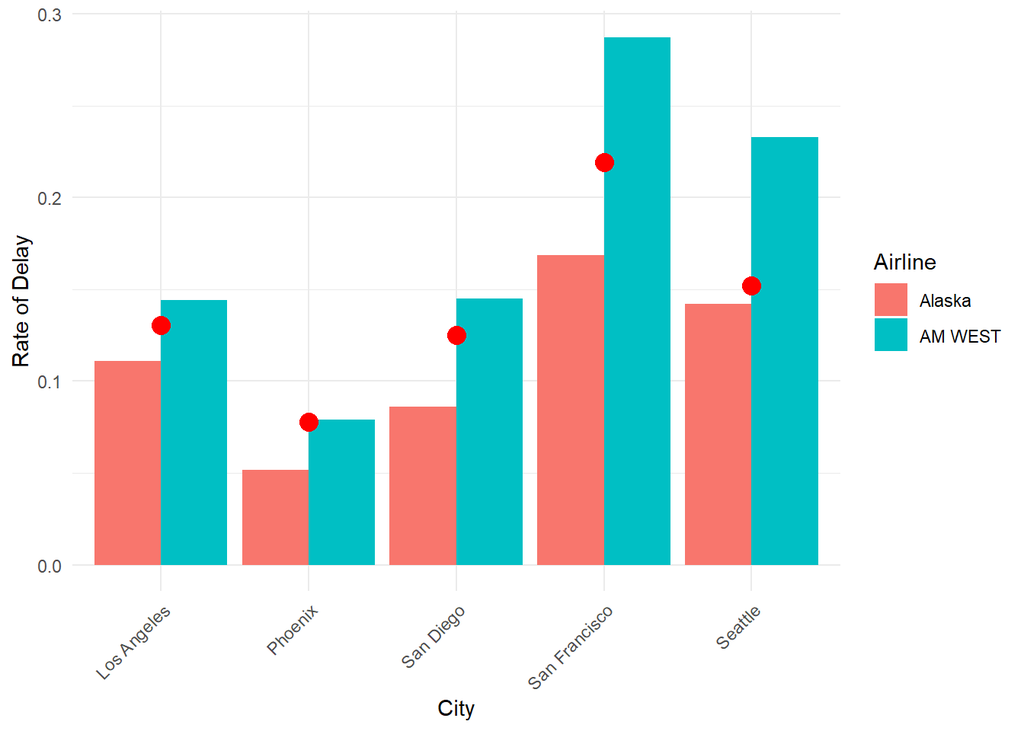

```r
ggplot() +
  # Bar plot for the rate of delay (
  geom_bar(data = flight_stats, aes(x = City, y = Rate_of_Delay, fill = Airline),
           stat = "identity", position = "dodge", show.legend = TRUE) +
  geom_point(data = flight_stats_city, aes(x = City, y = Rate_of_Delay),
             color = "red", size = 4, shape = 16, show.legend = FALSE) +
  # Labels and title
  labs(x = "City",
       y = "Rate of Delay") +
  theme_minimal() +
  theme(axis.text.x = element_text(angle = 45, hjust = 1))
```

### Conclusion

When analyzing data its important to consider groupings of variables that might be affecting your results. This data set is a good example for understanding the Simpsons paradox where the relationship between variables reverse or disappear when grouped using another variable.